# Regression_Models_Project

Sai krishnan

Sunday, January 18, 2015

# Automobile Industry Analysis for the Motor Trend Magazine

## Executive Summary

The requirement of this project is to analyze the MTCARS dataset and answer the following questions:-

1. Is an automatic or manual transmission better for MPG
2. Quantify the MPG difference between automatic and manual transmissions

Each row in the MTCARS dataset lists the following parameters pertaining to different car models:-

[, 1] mpg Miles/(US) gallon  
[, 2] cyl Number of cylinders  
[, 3] disp Displacement (cu.in.)  
[, 4] hp Gross horsepower  
[, 5] drat Rear axle ratio  
[, 6] wt Weight (lb/1000)  
[, 7] qsec 1/4 mile time  
[, 8] vs V/S  
[, 9] am Transmission (0 = automatic, 1 = manual)  
[,10] gear Number of forward gears  
[,11] carb Number of carburetors

We explore the relationship of MPG versus cylinders, horsepower and weight the variables with both manual and automatic transmission by building multi regression linear models.

Manual transmission cars have a better MPG than auto transmission. The quntitative difference between the models is obtained by subtracting the respective eqautions. This is documented in the results section.

## Data Processing

Read the file into R as follows:-

```r
library(datasets)
data(mtcars)
```

There are 32 observations (rows) with 11 parameters observed for each car in the dataset.

```r
dim(mtcars)
```

```
## [1] 32 11
```

We check the first few rows in the dataset.

```r
head(mtcars)
```

```
##                    mpg cyl disp  hp drat    wt  qsec vs am gear carb
## Mazda RX4         21.0   6  160 110 3.90 2.620 16.46  0  1    4    4
## Mazda RX4 Wag     21.0   6  160 110 3.90 2.875 17.02  0  1    4    4
## Datsun 710        22.8   4  108  93 3.85 2.320 18.61  1  1    4    1
## Hornet 4 Drive    21.4   6  258 110 3.08 3.215 19.44  1  0    3    1
## Hornet Sportabout 18.7   8  360 175 3.15 3.440 17.02  0  0    3    2
## Valiant           18.1   6  225 105 2.76 3.460 20.22  1  0    3    1
```

The column names lend themselves to processing by R. There are no NA values in these fields and all fields have numeric values. We take a look at the summary statistics of the ‘MTCARS’ data.

```r
summary(mtcars)
```

```
##       mpg             cyl             disp             hp
##  Min.   :10.40   Min.   :4.000   Min.   : 71.1   Min.   : 52.0
##  1st Qu.:15.43   1st Qu.:4.000   1st Qu.:120.8   1st Qu.: 96.5
##  Median :19.20   Median :6.000   Median :196.3   Median :123.0
##  Mean   :20.09   Mean   :6.188   Mean   :230.7   Mean   :146.7
##  3rd Qu.:22.80   3rd Qu.:8.000   3rd Qu.:326.0   3rd Qu.:180.0
##  Max.   :33.90   Max.   :8.000   Max.   :472.0   Max.   :335.0
##       drat             wt             qsec             vs
##  Min.   :2.760   Min.   :1.513   Min.   :14.50   Min.   :0.0000
##  1st Qu.:3.080   1st Qu.:2.581   1st Qu.:16.89   1st Qu.:0.0000
##  Median :3.695   Median :3.325   Median :17.71   Median :0.0000
##  Mean   :3.597   Mean   :3.217   Mean   :17.85   Mean   :0.4375
##  3rd Qu.:3.920   3rd Qu.:3.610   3rd Qu.:18.90   3rd Qu.:1.0000
##  Max.   :4.930   Max.   :5.424   Max.   :22.90   Max.   :1.0000
##        am              gear            carb
##  Min.   :0.0000   Min.   :3.000   Min.   :1.000
##  1st Qu.:0.0000   1st Qu.:3.000   1st Qu.:2.000
##  Median :0.0000   Median :4.000   Median :2.000
##  Mean   :0.4062   Mean   :3.688   Mean   :2.812
##  3rd Qu.:1.0000   3rd Qu.:4.000   3rd Qu.:4.000
##  Max.   :1.0000   Max.   :5.000   Max.   :8.000
```

We see that mean MPG for the 32 number of listed cars is 20.090625. There are 13 cars which are driven by manual transmission and 19 cars which have automatic transmission.

Let us separate out the cars with manual versus automatic transmission to compare their relationship to MPG.

```r
autoTrans   <- mtcars[mtcars$am==0,]
manualTrans <- mtcars[mtcars$am==1,]
summary(autoTrans)
```

```
##       mpg             cyl             disp             hp
##  Min.   :10.40   Min.   :4.000   Min.   :120.1   Min.   : 62.0
##  1st Qu.:14.95   1st Qu.:6.000   1st Qu.:196.3   1st Qu.:116.5
##  Median :17.30   Median :8.000   Median :275.8   Median :175.0
##  Mean   :17.15   Mean   :6.947   Mean   :290.4   Mean   :160.3
##  3rd Qu.:19.20   3rd Qu.:8.000   3rd Qu.:360.0   3rd Qu.:192.5
##  Max.   :24.40   Max.   :8.000   Max.   :472.0   Max.   :245.0
##       drat             wt             qsec             vs
##  Min.   :2.760   Min.   :2.465   Min.   :15.41   Min.   :0.0000
##  1st Qu.:3.070   1st Qu.:3.438   1st Qu.:17.18   1st Qu.:0.0000
##  Median :3.150   Median :3.520   Median :17.82   Median :0.0000
##  Mean   :3.286   Mean   :3.769   Mean   :18.18   Mean   :0.3684
##  3rd Qu.:3.695   3rd Qu.:3.842   3rd Qu.:19.17   3rd Qu.:1.0000
##  Max.   :3.920   Max.   :5.424   Max.   :22.90   Max.   :1.0000
##        am         gear            carb
##  Min.   :0   Min.   :3.000   Min.   :1.000
##  1st Qu.:0   1st Qu.:3.000   1st Qu.:2.000
##  Median :0   Median :3.000   Median :3.000
##  Mean   :0   Mean   :3.211   Mean   :2.737
##  3rd Qu.:0   3rd Qu.:3.000   3rd Qu.:4.000
##  Max.   :0   Max.   :4.000   Max.   :4.000
```

```r
summary(manualTrans)
```

```
##       mpg             cyl             disp             hp
##  Min.   :15.00   Min.   :4.000   Min.   : 71.1   Min.   : 52.0
##  1st Qu.:21.00   1st Qu.:4.000   1st Qu.: 79.0   1st Qu.: 66.0
##  Median :22.80   Median :4.000   Median :120.3   Median :109.0
##  Mean   :24.39   Mean   :5.077   Mean   :143.5   Mean   :126.8
##  3rd Qu.:30.40   3rd Qu.:6.000   3rd Qu.:160.0   3rd Qu.:113.0
##  Max.   :33.90   Max.   :8.000   Max.   :351.0   Max.   :335.0
##       drat            wt             qsec             vs
##  Min.   :3.54   Min.   :1.513   Min.   :14.50   Min.   :0.0000
##  1st Qu.:3.85   1st Qu.:1.935   1st Qu.:16.46   1st Qu.:0.0000
##  Median :4.08   Median :2.320   Median :17.02   Median :1.0000
##  Mean   :4.05   Mean   :2.411   Mean   :17.36   Mean   :0.5385
##  3rd Qu.:4.22   3rd Qu.:2.780   3rd Qu.:18.61   3rd Qu.:1.0000
##  Max.   :4.93   Max.   :3.570   Max.   :19.90   Max.   :1.0000
##        am         gear            carb
##  Min.   :1   Min.   :4.000   Min.   :1.000
##  1st Qu.:1   1st Qu.:4.000   1st Qu.:1.000
##  Median :1   Median :4.000   Median :2.000
##  Mean   :1   Mean   :4.385   Mean   :2.923
##  3rd Qu.:1   3rd Qu.:5.000   3rd Qu.:4.000
##  Max.   :1   Max.   :5.000   Max.   :8.000
```

The mean MPG of cars with automatic transmission is 17 which is less than 24.39 which is the mean MPG of cars with manual transmission.

Let us try to compare the MPG differences due to type in transmission corresponding to each treatment statistically. We conduct a ‘t’ test to compare the MPG corresponding to automatic and manual transmissions respectively. The null hypothesis is that there is no difference in the mean MPG of manual transmission and automatic transmission cars.

```r
t.test(autoTrans$mpg - manualTrans$mpg)
```

```
##
##  One Sample t-test
##
## data:  autoTrans$mpg - manualTrans$mpg
## t = -5.7176, df = 18, p-value = 2.02e-05
## alternative hypothesis: true mean is not equal to 0
## 95 percent confidence interval:
##  -10.997156  -5.087055
## sample estimates:
## mean of x
## -8.042105
```

Based on the ‘t’ test, we can reject the null hypothesis that the mean MPG for automatic and manual transmission cars are same. We can conclude that the mean MPG for cars with manual transmission is better than the MPG of cars with automatic transmission.

Let us build models of MPG versus parameters like number of cylinders (cyl), horsepower (hp), weight (wt).

```r
# Linear models for cars with automatic transmission
fitautompg <- lm(autoTrans$mpg~factor(autoTrans$cyl))
fit1autompg <- update(fitautompg, autoTrans$mpg~factor(autoTrans$cyl) + autoTrans$hp)
fit2autompg <- update(fitautompg, autoTrans$mpg~factor(autoTrans$cyl) + autoTrans$hp + autoTrans$wt)

# Linear models for cars with manual transmission
fitmanualmpg <- lm(manualTrans$mpg~factor(manualTrans$cyl) + manualTrans$hp)
fit1manualmpg <- update(fitmanualmpg,manualTrans$mpg~factor(manualTrans$cyl) + manualTrans$hp)
fit2manualmpg <- update(fitmanualmpg,manualTrans$mpg~factor(manualTrans$cyl) + manualTrans$hp + manualTrans$wt)
```

Let us select the best model for cars with automatic transmission.

```r
anova(fitautompg,fit1autompg,fit2autompg)
```

```
## Analysis of Variance Table
##
## Model 1: autoTrans$mpg ~ factor(autoTrans$cyl)
## Model 2: autoTrans$mpg ~ factor(autoTrans$cyl) + autoTrans$hp
## Model 3: autoTrans$mpg ~ factor(autoTrans$cyl) + autoTrans$hp + autoTrans$wt
##   Res.Df    RSS Df Sum of Sq      F  Pr(>F)
## 1     16 96.877
## 2     15 71.572  1    25.306 6.5875 0.02238 *
## 3     14 53.780  1    17.791 4.6314 0.04933 *
## ---
## Signif. codes:  0 '***' 0.001 '**' 0.01 '*' 0.05 '.' 0.1 ' ' 1
```

The model comparison shows that model 3 (with Cylinders, HP and weight) is significant at 0.05 level and is therefore selected amongst the 3 auto transmission models.

The model summary for cars with automatic transmission is as follows:-

```r
summary(fit2autompg)
```

```
##
## Call:
## lm(formula = autoTrans$mpg ~ factor(autoTrans$cyl) + autoTrans$hp +
##     autoTrans$wt)
##
## Residuals:
##     Min      1Q  Median      3Q     Max
## -2.3401 -1.4713 -0.2626  1.2553  3.1599
##
## Coefficients:
##                        Estimate Std. Error t value Pr(>|t|)
## (Intercept)            30.40938    2.54816  11.934    1e-08 ***
## factor(autoTrans$cyl)6 -2.12445    1.59157  -1.335   0.2032
## factor(autoTrans$cyl)8 -2.73810    2.25739  -1.213   0.2452
## autoTrans$hp           -0.02799    0.01851  -1.512   0.1528
## autoTrans$wt           -1.75121    0.81373  -2.152   0.0493 *
## ---
## Signif. codes:  0 '***' 0.001 '**' 0.01 '*' 0.05 '.' 0.1 ' ' 1
##
## Residual standard error: 1.96 on 14 degrees of freedom
## Multiple R-squared:  0.7967, Adjusted R-squared:  0.7387
## F-statistic: 13.72 on 4 and 14 DF,  p-value: 9.428e-05
```

```r
autompgSummary <- summary(fit2autompg)
interceptAT  <- autompgSummary$coefficients[1,1]
beta6CylAT   <- autompgSummary$coefficients[2,1]
beta8CylAT   <- autompgSummary$coefficients[3,1]
betaHpAT     <- autompgSummary$coefficients[4,1]
betaWtAT     <- autompgSummary$coefficients[5,1]
```

The overall model equation for automatic transmission cars is:-  
MPG(AT) = 30.4093816 -2.1244485 x6CYL -2.7380988 x8CYL -0.0279871 xHP -1.7512116 xWT  
Based on the summary, we see that the ‘Pr’ value for weight is significant 0.0493267 (at p-value 0.05) as compared to the other parameters.

The coefficients of the following independent variables (from above equation) can be interpreted as follows:-

6CYL : Reduction in MPG as compared to a 4 cylinder engine  
8CYL : Reduction in MPG as compared to a 4 cylinder engine  
HP : Reduction in MPG due to unit increase in horsepower  
WT : Reduction in MPG due to 1 tonne increase in weight

Diagnostic plots are as follows:-

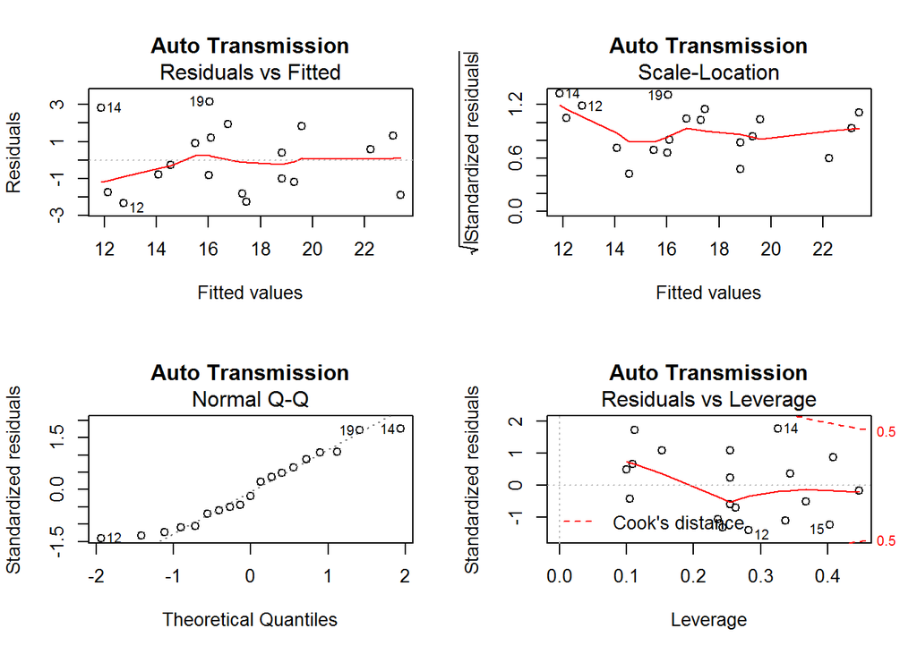

```r
layout(matrix(c(1,2,3,4),2,2))
plot(fit2autompg,main="Auto Transmission")
```

Now let us select a regression model to predict ‘MPG’ for manual transmission cars.

```r
anova(fitmanualmpg,fit1manualmpg,fit2manualmpg)
```

```
## Analysis of Variance Table
##
## Model 1: manualTrans$mpg ~ factor(manualTrans$cyl) + manualTrans$hp
## Model 2: manualTrans$mpg ~ factor(manualTrans$cyl) + manualTrans$hp
## Model 3: manualTrans$mpg ~ factor(manualTrans$cyl) + manualTrans$hp +
##     manualTrans$wt
##   Res.Df     RSS Df Sum of Sq      F  Pr(>F)
## 1      9 114.726
## 2      9 114.726  0     0.000
## 3      8  66.977  1    47.749 5.7033 0.04398 *
## ---
## Signif. codes:  0 '***' 0.001 '**' 0.01 '*' 0.05 '.' 0.1 ' ' 1
```

The model comparison shows that model 3 (with Cylinders, HP and weight) is significant at 0.05 level and is therefore selected amongst the 3 manual transmission models.

The model summary for cars with manual transmission is as follows:-

```r
summary(fit2manualmpg)
```

```
##
## Call:
## lm(formula = manualTrans$mpg ~ factor(manualTrans$cyl) + manualTrans$hp +
##     manualTrans$wt)
##
## Residuals:
##     Min      1Q  Median      3Q     Max
## -3.1568 -1.2853 -1.0447  0.6182  4.9158
##
## Coefficients:
##                          Estimate Std. Error t value Pr(>|t|)
## (Intercept)              43.65159    5.35622   8.150 3.82e-05 ***
## factor(manualTrans$cyl)6 -1.48679    2.83297  -0.525    0.614
## factor(manualTrans$cyl)8  1.98686    7.12847   0.279    0.788
## manualTrans$hp           -0.02759    0.03277  -0.842    0.424
## manualTrans$wt           -6.52126    2.73067  -2.388    0.044 *
## ---
## Signif. codes:  0 '***' 0.001 '**' 0.01 '*' 0.05 '.' 0.1 ' ' 1
##
## Residual standard error: 2.893 on 8 degrees of freedom
## Multiple R-squared:  0.8532, Adjusted R-squared:  0.7798
## F-statistic: 11.63 on 4 and 8 DF,  p-value: 0.002048
```

```r
manualmpgSummary <- summary(fit2manualmpg)
interceptMT  <- manualmpgSummary$coefficients[1,1]
beta6CylMT   <- manualmpgSummary$coefficients[2,1]
beta8CylMT   <- manualmpgSummary$coefficients[3,1]
betaHpMT     <- manualmpgSummary$coefficients[4,1]
betaWtMT     <- manualmpgSummary$coefficients[5,1]
```

The overall model equation for manual transmission cars is:-  
MPG(MT) = 43.6515928 -1.4867858 x6CYL 1.9868579 x8CYL -0.0275853 xHP -6.5212611 xWT  
Based on the summary, we see that the ‘Pr’ value for weight is significant 0.0439825 (at p-value 0.05) as compared to the other parameters.  
The coefficients of the following independent variables (from above equation) can be interpreted as follows:-

6CYL : Reduction in MPG as compared to a 4 cylinder engine  
8CYL : Increase in MPG as compared to a 4 cylinder engine  
HP : Reduction in MPG due to unit increase in horsepower  
WT : Reduction in MPG due to 1 tonne increase in weight  
Diagnostic plots are as follows:-

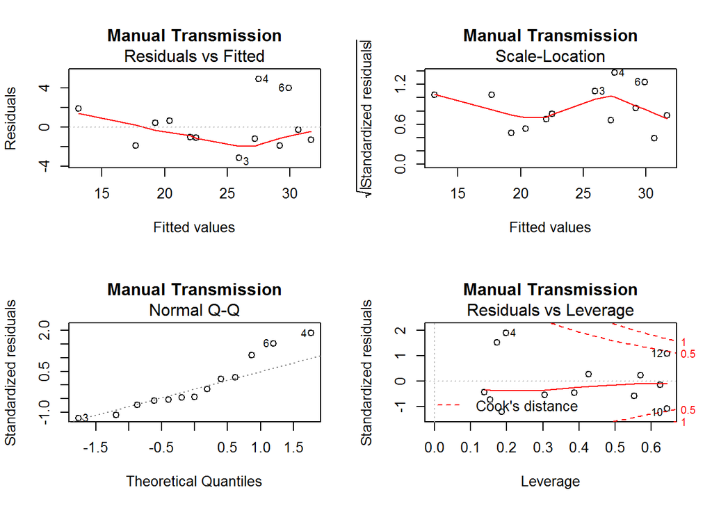

```r
layout(matrix(c(1,2,3,4),2,2))
plot(fit2manualmpg,main="Manual Transmission")
```

## Results

MPG(MT) - MPG(AT) = 13.2422112 + 0.6376627 x6CYL + 4.7249567 x8CYL + 4.018012310^{-4}xHP -4.7700495xWT